# analyseDiversity — Diversité des collemboles en sols urbains

```r
library(dplyr)
library(vegan)
library(tibble)
library(ggplot2)
library(tidyr)

theme_set(theme_minimal())
```

**Que fait ce code ?** On charge les packages utiles : `dplyr` (manipulation des données), `vegan` (indices de diversité), `tibble`, `ggplot2` et `tidyr` (graphiques).

# 1 Contexte

Les **collemboles** sont de petits insectes du sol (moins de 2 mm). Ils font partie de la mésofaune et sont de bons **bioindicateurs** de la qualité des sols, surtout en ville.

Deux fichiers de données sont utilisés :

- `collembola_data_year1_train.csv` : comptages de collemboles par échantillon.
- `BISES_data_sites.csv` : caractéristiques du sol de chaque site (pH, texture, métaux…) + la ville et l’usage du sol.

Objectif : calculer des **indices de diversité** par site, puis vérifier s’ils s’expliquent par les caractéristiques du sol et le contexte urbain.

# 2 Importation et préparation des données

```r
data1 <- read.csv2("data/collembola_data_year1_train.csv", header = TRUE)
data_site <- read.csv2("data/BISES_data_sites.csv", header = TRUE)

nb_vars_initial <- ncol(data1)

cols_to_remove <- c(
  "total_collembola", "Acari_Gamasides", "Acari_Oribates",
  "Acari_others", "Acari_total", "Other_microarthropodes",
  "total_microarthropodes"
)

df_spe <- data1 %>%
  select(-any_of(cols_to_remove)) %>%
  mutate(ID_base = sub("_[0-9]+$", "", Echantillon)) %>%
  select(-Echantillon) %>%
  group_by(ID_base) %>%
  summarise(across(where(is.numeric), \(x) sum(x, na.rm = TRUE)), .groups = "drop") %>%
  column_to_rownames(var = "ID_base")

nb_especes <- ncol(df_spe)

A <- rowSums(df_spe)
S <- specnumber(df_spe)
H <- diversity(df_spe, index = "shannon")
J <- H / log(S)

indices_ecologiques <- data.frame(
  ID_base = rownames(df_spe),
  Abondance_A = A,
  Richesse_S = S,
  Shannon_H = H,
  Pielou_J = J
)

donnees_completes <- indices_ecologiques %>%
  left_join(data_site, by = c("ID_base" = "Site"))

factors <- c("site_group", "land_use", "city")

for (factor in factors) {
  if (factor %in% colnames(donnees_completes)) {
    donnees_completes[[factor]] <- as.factor(donnees_completes[[factor]])
  }
}

donnees_completes <- na.omit(donnees_completes)

cat("Sites après préparation :", nrow(donnees_completes), "\n")
```

```
## Sites après préparation : 137
```

```r
cat("Nombre de taxons :", nb_especes, "\n")
```

```
## Nombre de taxons : 99
```

**Explication du code, étape par étape :**

1. `read.csv2(...)` : lit les deux fichiers CSV (le séparateur est `;`, format français).
2. `cols_to_remove` : liste des colonnes à enlever (acariens, totaux…). On ne garde que les collemboles.
3. `select(-any_of(...))` : supprime ces colonnes.
4. `sub("_[0-9]+$", "", Echantillon)` : enlève le suffixe `_1`, `_2`… du nom des échantillons. Exemple : `BISES_MO_FU_CDN_2` devient `BISES_MO_FU_CDN`. Les prélèvements d’un même site ont ainsi le même nom `ID_base`.
5. `group_by(ID_base) + summarise(sum(...))` : **somme les abondances par site**. On passe de 418 prélèvements à 140 sites.
6. `column_to_rownames` : le nom du site devient le nom de la ligne.
7. `rowSums`, `specnumber`, `diversity` : calculent les 4 indices (voir section suivante).
8. `left_join(data_site)` : ajoute au tableau des indices les colonnes du sol correspondant à chaque site.
9. `as.factor` : transforme `city`, `land_use` et `site_group` en variables qualitatives.
10. `na.omit` : enlève les sites avec des valeurs manquantes (137 sites restants).

# 3 Indices écologiques ($\alpha$-diversité)

Pour chaque site, on calcule 4 indices. Ce sont nos **variables à expliquer ($Y$)** :

### 3.0.1 1. Abondance totale ($A$)

Nombre total d’individus récoltés dans l’échantillon :
$$A = \sum_{i=1}^{S} n_i$$
Mesure la **quantité** d’animaux, pas la diversité.

### 3.0.2 2. Richesse spécifique ($S$)

Nombre total d’espèces présentes :
$$S =
\text{Nombre d'espèces avec } n_i > 0$$
`specnumber(df_spe)` compte les colonnes non nulles de chaque ligne.

### 3.0.3 3. Indice de Shannon ($H$)

$$H = -\sum_{i=1}^{S} p_i \ln(p_i) \quad
\text{où } p_i = \frac{n_i}{A}$$
$H$ est **grand** quand il y a beaucoup d’espèces bien réparties, **petit** quand une espèce domine.

### 3.0.4 4. Équitabilité de Pielou ($J$)

$$J = \frac{H}{\ln(S)}$$
Même idée que Shannon, mais ramenée entre 0 et 1 : $J$ proche de 1 = espèces équitablement réparties, proche de 0 = une espèce domine.

# 4 Graphiques

## 4.1 Espèces les plus abondantes

[figure not shown]

```r
abondance_especes <- sort(colSums(df_spe), decreasing = TRUE)
top_especes <- head(abondance_especes, 10)

barplot(
  top_especes,
  horiz = TRUE,
  las = 1,
  col = "steelblue",
  border = NA,
  main = "Les 10 espèces les plus abondantes",
  xlab = "Nombre total d'individus"
)
```

**Explication du code :** `colSums(df_spe)` fait la somme de chaque espèce sur tous les sites, `sort(..., decreasing = TRUE)` les trie de la plus abondante à la plus rare, `head(..., 10)` garde les 10 premières, et `barplot` dessine le diagramme en barres.

## 4.2 Distribution des 4 indices

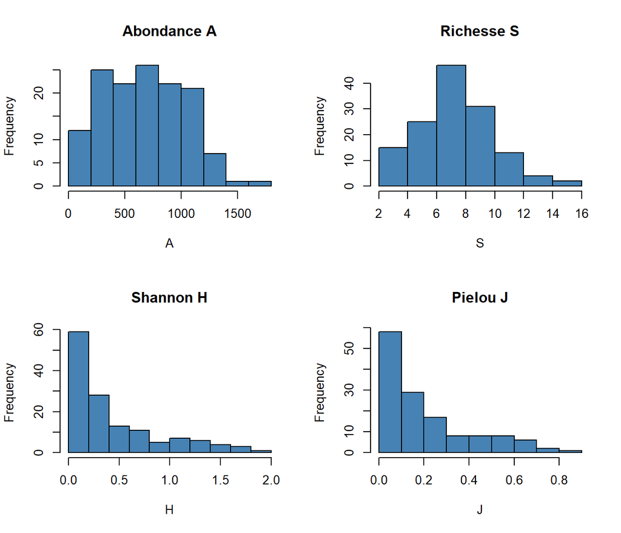

```r
par(mfrow = c(2, 2))
hist(donnees_completes$Abondance_A, main = "Abondance A", xlab = "A", col = "steelblue")
hist(donnees_completes$Richesse_S, main = "Richesse S", xlab = "S", col = "steelblue")
hist(donnees_completes$Shannon_H, main = "Shannon H", xlab = "H", col = "steelblue")
hist(donnees_completes$Pielou_J, main = "Pielou J", xlab = "J", col = "steelblue")
```

```r
par(mfrow = c(1, 1))
```

**Explication du code :** `par(mfrow = c(2, 2))` affiche 4 graphiques sur une même figure (2 lignes, 2 colonnes). Chaque `hist(...)` trace l’histogramme d’un indice.

**Ce qu’on voit :**

- $A$ : de 36 à 1722 individus, avec la plupart des sites entre 200 et 1000.
- $S$ : entre 2 et 16 espèces.
- $H$ et $J$ : la majorité des valeurs sont proches de 0, donc des communautés dominées par peu d’espèces.

## 4.3 Effet de l’usage du sol

Le code d’usage (`land_use`) correspond à un groupe écologique : FU et JP = production alimentaire (*Food Production*), PU = loisirs (*Leisure*), LV et RP = trafic (*Traffic*).

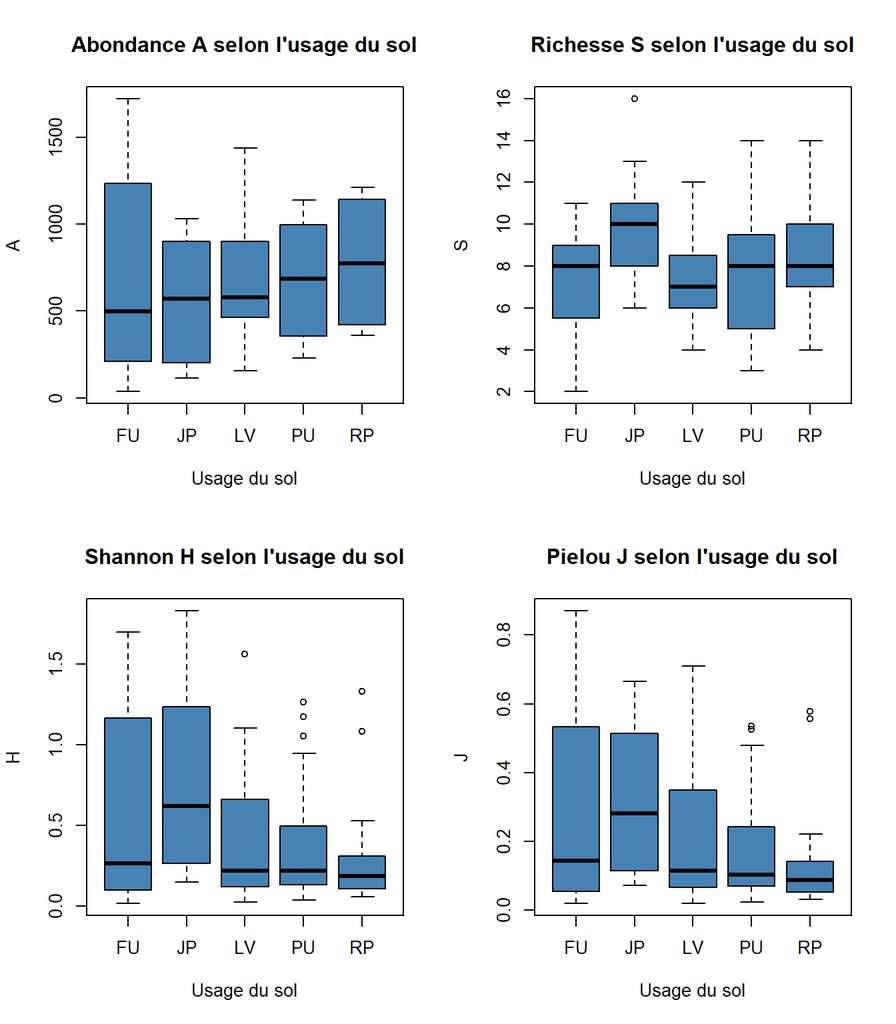

```r
par(mfrow = c(2, 2))
boxplot(Abondance_A ~ land_use, data = donnees_completes,
        main = "Abondance A selon l'usage du sol", xlab = "Usage du sol", ylab = "A",
        col = "steelblue")
boxplot(Richesse_S ~ land_use, data = donnees_completes,
        main = "Richesse S selon l'usage du sol", xlab = "Usage du sol", ylab = "S",
        col = "steelblue")
boxplot(Shannon_H ~ land_use, data = donnees_completes,
        main = "Shannon H selon l'usage du sol", xlab = "Usage du sol", ylab = "H",
        col = "steelblue")
boxplot(Pielou_J ~ land_use, data = donnees_completes,
        main = "Pielou J selon l'usage du sol", xlab = "Usage du sol", ylab = "J",
        col = "steelblue")
```

```r
par(mfrow = c(1, 1))
```

**Explication du code :** `boxplot(Y ~ land_use, ...)` trace un diagramme en boîte de l’indice `Y` pour chaque usage du sol. La formule `Y ~ land_use` se lit « Y en fonction de land_use ».

**Ce qu’on voit :**

- $A$ : les abondances sont assez proches d’un usage à l’autre.
- $S$ : les jardins (JP) sont les plus riches en espèces.
- $H$ et $J$ : plus élevés pour les usages de production (FU, JP). Les sites de trafic (RP, LV) et de loisirs (PU) ont des communautés plus déséquilibrées.

## 4.4 Effet de la ville

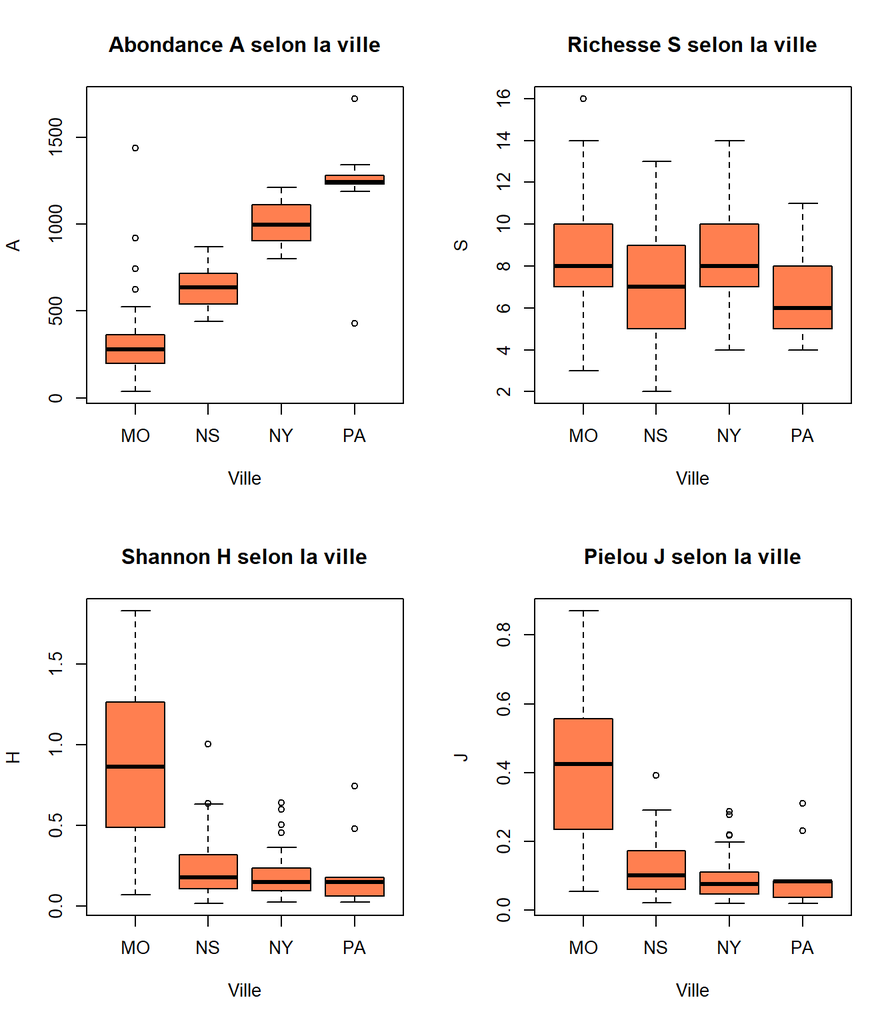

```r
par(mfrow = c(2, 2))
boxplot(Abondance_A ~ city, data = donnees_completes,
        main = "Abondance A selon la ville", xlab = "Ville", ylab = "A",
        col = "coral")
boxplot(Richesse_S ~ city, data = donnees_completes,
        main = "Richesse S selon la ville", xlab = "Ville", ylab = "S",
        col = "coral")
boxplot(Shannon_H ~ city, data = donnees_completes,
        main = "Shannon H selon la ville", xlab = "Ville", ylab = "H",
        col = "coral")
boxplot(Pielou_J ~ city, data = donnees_completes,
        main = "Pielou J selon la ville", xlab = "Ville", ylab = "J",
        col = "coral")
```

```r
par(mfrow = c(1, 1))
```

**Explication du code :** même principe, mais avec la variable `city`.

**Ce qu’on voit :** la ville est très marquante. MO a peu d’individus mais des communautés équilibrées ($H$ et $J$ élevés). À l’inverse, NY et PA ont de très grandes abondances mais des $H$ et $J$ très bas : une espèce y explose. Les sites les plus abondants ne sont donc pas les plus diversifiés.

# 5 Modélisation linéaire

## 5.1 Stratégie

On veut **expliquer** les indices de diversité avec les variables du sol et le contexte. Pour ça :

1. Ajuster un modèle linéaire `lm()` pour **chacun des 4 indices** avec toutes les variables explicatives.
2. Comparer les **$R^2$ ajustés** : celui qui est le plus grand indique l’indice le mieux expliqué. On utilise la version *ajustée* car elle pénalise le grand nombre de variables.
3. Garder le meilleur indice, puis **retirer une par une** les variables non significatives ($p$-valeur $\geq 0{,}05$) pour simplifier le modèle.

## 5.2 Quel indice modéliser ?

```r
Y <- c("Abondance_A", "Richesse_S", "Shannon_H", "Pielou_J")

trouver_meilleur_y <- function(vector_y, df_complet) {
  best_model <- NULL
  best_y <- NULL
  best_r2_adj <- -Inf

  for (y in vector_y) {
    X <- df_complet %>%
      select(-any_of(vector_y), -any_of("ID_base"))

    df_modele <- cbind(y = df_complet[[y]], X)

    model <- lm(y ~ ., data = df_modele)

    r2_adj <- summary(model)$adj.r.squared

    if (!is.na(r2_adj) && r2_adj > best_r2_adj) {
      best_model <- model
      best_y <- y
      best_r2_adj <- r2_adj
    }
  }

  return(list(
    model = best_model,
    best_y = best_y,
    adj_r2 = best_r2_adj
  ))
}
```

**Explication du code :**

- La fonction teste les 4 indices les uns après les autres (`for (y in vector_y)`).
- `select(-any_of(vector_y), -any_of("ID_base"))` garde uniquement les variables explicatives (on enlève les 4 indices et le nom du site).
- `cbind(y = ..., X)` remet l’indice testé dans le tableau, sous le nom générique `y`.
- `lm(y ~ ., data = df_modele)` ajuste le modèle : `y` expliqué par **toutes** les autres colonnes (le point `.` veut dire « toutes les variables »).
- `summary(model)$adj.r.squared` extrait le $R^2$ ajusté.
- Si ce $R^2$ est le meilleur jusqu’ici, on garde ce modèle, cet indice et cette valeur.

```r
resultat <- trouver_meilleur_y(
  vector_y = Y,
  df_complet = donnees_completes
)

cat("Meilleure variable Y :", resultat$best_y, "\n")
```

```
## Meilleure variable Y : Abondance_A
```

```r
cat("R2 ajuste :", round(resultat$adj_r2, 4), "\n\n")
```

```
## R2 ajuste : 0.8081
```

```r
summary(resultat$model)
```

```
##
## Call:
## lm(formula = y ~ ., data = df_modele)
##
## Residuals:
##     Min      1Q  Median      3Q     Max
## -698.70  -59.94   -9.25   34.40  824.73
##
## Coefficients: (2 not defined because of singularities)
##                     Estimate Std. Error t value Pr(>|t|)
## (Intercept)       55062.8338 29402.8038   1.873  0.06397 .
## Argile              -53.8388    29.3000  -1.838  0.06905 .
## Limon               -54.1074    29.4540  -1.837  0.06912 .
## Sable               -54.0432    29.4319  -1.836  0.06924 .
## Conduct            -472.0255   469.6174  -1.005  0.31721
## pH.eau              -42.0943    43.6738  -0.964  0.33741
## Carbonates            0.2976     0.4348   0.684  0.49525
## Calcaire             -1.0846     1.4678  -0.739  0.46162
## C..orga             522.8538   366.1725   1.428  0.15638
## Mat_org            -293.7385   212.4664  -1.383  0.16983
## Azote              -157.9348   123.2539  -1.281  0.20297
## C.N                 -56.6696    34.3359  -1.650  0.10193
## P2O5                 63.1742   339.4997   0.186  0.85275
## CEC                   0.1973     0.9747   0.202  0.84003
## K2O                 261.2915   114.4809   2.282  0.02454 *
## MgO                -334.2527   191.7096  -1.744  0.08425 .
## CaO                   4.1786    18.8402   0.222  0.82492
## Na2O                204.2000   477.0145   0.428  0.66950
## Al                    1.5600     2.9004   0.538  0.59185
## Cd                  103.9676   220.1072   0.472  0.63769
## Co                    4.7723    11.8652   0.402  0.68837
## Cr                    0.2071     1.7219   0.120  0.90448
## Cu                    0.5669     0.6237   0.909  0.36553
## Fe                   -3.0496     3.7037  -0.823  0.41220
## Mn                   36.2411    97.0308   0.374  0.70955
## Ni                   -1.8532     2.6374  -0.703  0.48387
## Pb                   -0.2265     0.3284  -0.690  0.49201
## Zn                    0.2863     0.4650   0.616  0.53946
## cityNS              278.7081   131.2567   2.123  0.03614 *
## cityNY              690.5890    85.4979   8.077 1.39e-12 ***
## cityPA              971.9435   111.1154   8.747 4.77e-14 ***
## land_useJP          -68.9564    62.8853  -1.097  0.27542
## land_useLV           95.2070    66.0566   1.441  0.15256
## land_usePU          190.9470    62.3476   3.063  0.00281 **
## land_useRP          299.0431    63.2714   4.726 7.34e-06 ***
## site_groupLeisure         NA         NA      NA       NA
## site_groupTraffic         NA         NA      NA       NA
## ---
## Signif. codes:  0 '***' 0.001 '**' 0.01 '*' 0.05 '.' 0.1 ' ' 1
##
## Residual standard error: 157.7 on 102 degrees of freedom
## Multiple R-squared:  0.8561, Adjusted R-squared:  0.8081
## F-statistic: 17.84 on 34 and 102 DF,  p-value: < 2.2e-16
```

## 5.3 Sélection des variables (élimination descendante)

Le modèle complet contient trop de variables, dont beaucoup ne servent à rien. On retire donc, une par une, les variables **non significatives** :

- à chaque tour, on regarde les $p$-valeurs du modèle courant ;
- on enlève la variable la moins significative ($p$-valeur la plus grande, $\geq 0{,}05$) ;
- on recommence jusqu’à ce que toutes les variables restantes soient significatives.

Point de vigilance : une variable qualitative comme `land_use` produit **plusieurs** coefficients (un par modalité : `land_useJP`, `land_useLV`…). On regroupe donc les $p$-valeurs par variable d’origine pour décider si on garde ou retire `land_use` en entier.

```r
filtrer_variables_pvalue <- function(df_complet, y_nom = "Abondance_A", alpha = 0.05) {
  indices_a_exclure <- c("Abondance_A", "Richesse_S", "Shannon_H", "Pielou_J",
                         "ID_base", "Echantillon")
  X <- df_complet %>%
    select(-any_of(indices_a_exclure))

  noms_colonnes <- colnames(X)

  df_modele <- cbind(y = df_complet[[y_nom]], X)

  modele <- lm(y ~ ., data = df_modele)

  continuer <- TRUE

  while (continuer) {
    # 1) p-valeurs des coefficients du modèle courant
    coef_table <- summary(modele)$coefficients
    p_vals <- coef_table[, "Pr(>|t|)"]
    p_vals <- p_vals[names(p_vals) != "(Intercept)"]

    if (length(p_vals) == 0) {
      message("Aucune variable restante dans le modèle.")
      return(NULL)
    }

    # 2) Retrouver la variable d'origine de chaque coefficient
    #    (land_useLV vient de la variable land_use, cityPA de city, ...)
    vars_associees <- sapply(names(p_vals), function(v) {
      match <- noms_colonnes[sapply(noms_colonnes, function(col) startsWith(v, col))]
      if (length(match) > 0) {
        match <- match[order(nchar(match), decreasing = TRUE)]
        return(match[1])
      } else {
        return(v)
      }
    })

    df_p <- data.frame(
      var_origin = vars_associees,
      p_val = p_vals,
      stringsAsFactors = FALSE
    )

    # 3) p-valeur minimale de chaque variable (toutes modalités confondues)
    min_p_per_var <- aggregate(p_val ~ var_origin, data = df_p, FUN = min)
    vars_non_sig <- min_p_per_var[min_p_per_var$p_val >= alpha, ]

    # 4) Si tout est significatif, on a fini
    if (nrow(vars_non_sig) == 0) {
      continuer <- FALSE
    } else {
      # Sinon on retire la variable la moins significative et on recommence
      var_a_retirer <- vars_non_sig$var_origin[which.max(vars_non_sig$p_val)]
      vars_actuelles <- unique(vars_associees)
      vars_restantes <- setdiff(vars_actuelles, var_a_retirer)

      if (length(vars_restantes) == 0) {
        message("Toutes les variables ont été éliminées (p >= ", alpha, ").")
        return(NULL)
      }

      df_modele <- cbind(y = df_complet[[y_nom]], X[, vars_restantes, drop = FALSE])
      modele <- lm(y ~ ., data = df_modele)
    }
  }

  return(modele)
}
```

**Explication du code :**

- `indices_a_exclure` : on enlève les 4 indices et les identifiants, il ne reste que les variables explicatives dans `X`.
- La boucle `while (continuer)` tourne tant qu’il reste des variables non significatives.
- `summary(modele)$coefficients` récupère le tableau des coefficients, dont la colonne `"Pr(>|t|)"` contient les $p$-valeurs. On enlève l’ordonnée à l’origine.
- La partie 2) remonte du nom d’un coefficient (`cityPA`) au nom de la variable (`city`) : on garde la colonne de `X` qui correspond au début du nom.
- `aggregate(p_val ~ var_origin, FUN = min)` garde la plus petite $p$-valeur de chaque variable : une variable qualitative est conservée dès qu’une de ses modalités est significative.
- `which.max` désigne la variable à retirer (la moins significative), `setdiff` l’enlève de la liste, puis on relance `lm()` sur les variables restantes.

```r
modele_p005 <- filtrer_variables_pvalue(
  df_complet = donnees_completes,
  y_nom = resultat$best_y,
  alpha = 0.05
)

if (!is.null(modele_p005)) {
  cat("Variables retenues :", paste(names(coef(modele_p005))[-1], collapse = ", "), "\n")
  cat("R2 ajusté du modèle final :", round(summary(modele_p005)$adj.r.squared, 4), "\n\n")
  summary(modele_p005)
}
```

```
## Variables retenues : K2O, MgO, cityNS, cityNY, cityPA, land_useJP, land_useLV, land_usePU, land_useRP
## R2 ajusté du modèle final : 0.8195
```

```
##
## Call:
## lm(formula = y ~ ., data = df_modele)
##
## Residuals:
##     Min      1Q  Median      3Q     Max
## -817.15  -61.85  -14.57   40.94 1014.73
##
## Coefficients:
##             Estimate Std. Error t value Pr(>|t|)
## (Intercept)   173.42      49.14   3.529 0.000581 ***
## K2O           188.49      77.42   2.435 0.016295 *
## MgO          -255.68     114.45  -2.234 0.027226 *
## cityNS        304.48      33.55   9.076 1.82e-15 ***
## cityNY        687.75      33.43  20.573  < 2e-16 ***
## cityPA       1022.41      64.21  15.923  < 2e-16 ***
## land_useJP    -16.65      51.37  -0.324 0.746427
## land_useLV    123.41      49.90   2.473 0.014707 *
## land_usePU    207.08      46.13   4.489 1.58e-05 ***
## land_useRP    326.11      50.71   6.431 2.35e-09 ***
## ---
## Signif. codes:  0 '***' 0.001 '**' 0.01 '*' 0.05 '.' 0.1 ' ' 1
##
## Residual standard error: 152.9 on 127 degrees of freedom
## Multiple R-squared:  0.8314, Adjusted R-squared:  0.8195
## F-statistic: 69.59 on 9 and 127 DF,  p-value: < 2.2e-16
```

## 5.4 Lecture des résultats

Les modalités se comparent à la **référence** (ville MO, usage FU) :

- **Ville** : NS, NY et PA ont plus d’individus que MO, toutes choses égales par ailleurs. C’est l’effet le plus fort du modèle.
- **Usage du sol** : les usages loisirs (PU) et trafic (LV, RP) ont plus d’individus que la production alimentaire (FU). JP n’est pas significativement différent de FU.
- **Sol** : plus de potassium (`K2O`) = plus d’individus ; plus de magnésium (`MgO`) = moins d’individus.

## 5.5 Vérification du modèle

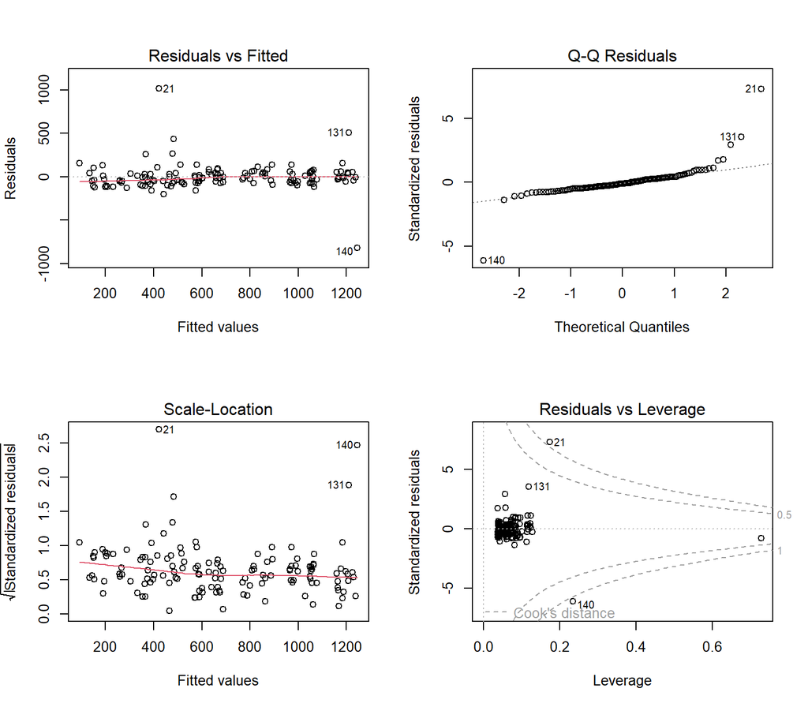

```r
par(mfrow = c(2, 2))
plot(modele_p005)
```

```r
par(mfrow = c(1, 1))
```

**Explication du code :** `plot(modele)` affiche les 4 graphiques de diagnostic standards d’un modèle linéaire. On vérifie que les résidus n’ont pas de structure (1er graphique), qu’ils suivent la droite sur le Q-Q plot (2e), que leur dispersion est constante (3e) et qu’aucun site n’est trop influent (4e).

## 5.6 Observé vs prédit

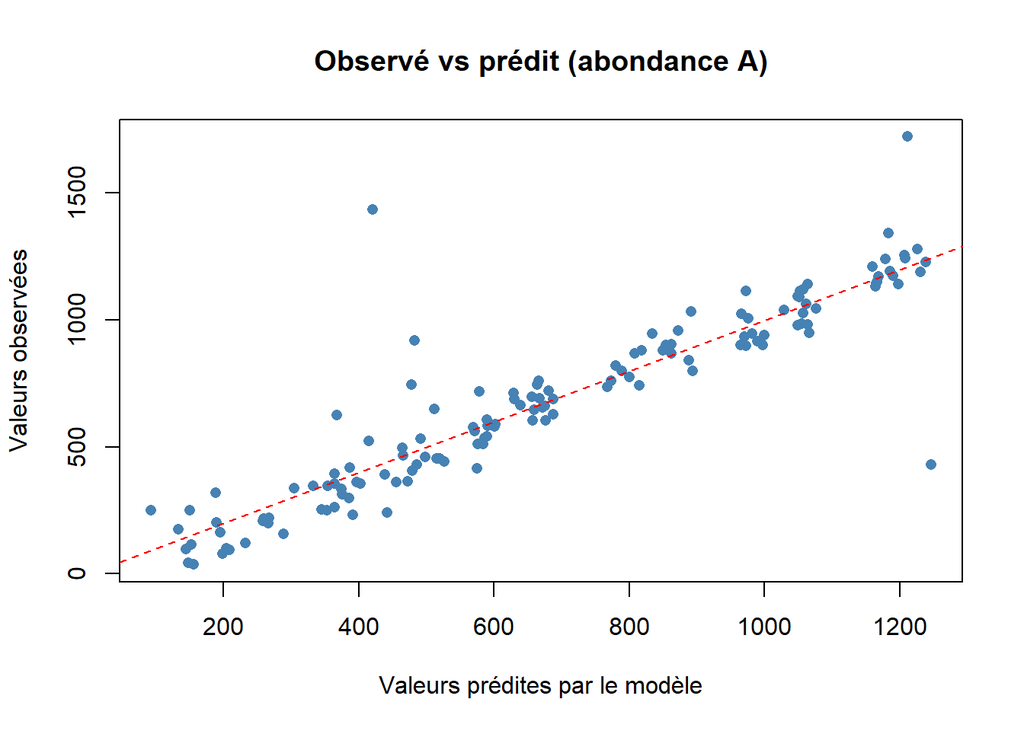

```r
plot(
  fitted(modele_p005), donnees_completes$Abondance_A,
  xlab = "Valeurs prédites par le modèle",
  ylab = "Valeurs observées",
  main = "Observé vs prédit (abondance A)",
  pch = 16, col = "steelblue"
)
abline(0, 1, col = "red", lty = 2)
```

**Explication du code :** `fitted(modele_p005)` donne les valeurs prédites par le modèle pour chaque site. On les compare aux valeurs observées. La droite rouge est la première bissectrice : si le modèle était parfait, tous les points seraient dessus.

**Ce qu’on voit :** les points suivent bien la droite, le modèle prédit raisonnablement l’abondance de chaque site.

# 6 Conclusion

**Limites** : ce sont des données observationnelles, on ne peut pas parler de causalité ; les variables du sol sont corrélées entre elles ; et la ville PA ne compte que 9 sites, ce qui rend son estimation fragile.